# SP26 EEG Study Results

# Participants

- The behavioural analysis included 46 participants, 22 first language (L1) speakers and 24 second language (L2) learners of Spanish.
- The event-related potential (ERP) analysis included 40 participants (19 L1, 21 L2). Participants with fewer than 50% artifact-free epochs at any analysed event were excluded.

# Analysis

- Reaction times were calculated from suffix onset at pre and post and from stem offset in training. The audio output delay measured in each trial was subtracted.
- Reaction times between 200 and 5000 ms after suffix onset were log-transformed and analysed with linear mixed-effects models. Correct and incorrect responses were both included in the reaction time models, and Accuracy was included as a variable.
- One training stem was excluded from the training analysis because its sound file was cut too early.
- Response accuracy was analysed with generalised linear mixed-effects models.
- The models of the pre test (pre) and the post test (post) included Group, Phase, and Match as fixed effects, with Participant and Item as random effects. The training models included Group, Trial Number, and Verb Stress.
- Mean ERP amplitudes were measured after the fundamental frequency (F0) event of the noun, the F0 event of the verb, and the suffix onset.
- The PrAN to verb stress was measured at the centrofrontal electrodes (F3, FCz, FC1, and Cz) and at the left anterior electrodes (F7, F3, and FC5).
- The PrAN to the noun cue was measured from 136 to 280 ms at the centrofrontal electrodes, and from 136 to 200 ms at the centrofrontal and the left anterior electrodes.
- The duration, the fundamental frequency, and the intensity of each syllable of the noun were measured in the two versions of each noun with the Praat algorithms. The syllable boundaries are from the TextGrid of each sound.
- In training, the mean amplitude from 600 to 800 ms after verb F0 was related to the reaction time of each trial with a linear mixed-effects model.
- Cluster-based permutation tests of the same comparisons over all electrodes, in the time window of each component, are reported on the Cluster tests page.
- Every effect of the ANOVAs at pre and post was also tested with a permutation test on difference scores, with 10,000 permutations. A difference score is one value per participant and phase, for example the amplitude for mismatched suffixes minus the amplitude for matched suffixes. The ANOVA and the permutation test gave the same decision at *p* < .05 for 171 of 171 effects. Both *p* values are in the last table. The training ANOVA has four blocks and is not included.
- Mean ERP amplitudes were analysed with mixed analyses of variance (ANOVAs) with Group as a between-participant factor and Phase, Verb Stress, and Match as within-participant factors. Pairwise comparisons were corrected for the false discovery rate (FDR).

# Summary of significant results

**Behavioural**

- **Verb cue, reaction times.** L1 participants responded more slowly to mismatched than to matched suffixes at pre (*M* = 994 ms vs. 963 ms, *z* = 3.86, *p* < .001) and at post (*M* = 868 ms vs. 820 ms, *z* = 5.95, *p* < .001). L2 participants did not (Group × Verb Match, *β* = −0.028, *SE* = 0.008, *t* = −3.53, *p* < .001).
- **Verb cue, accuracy.** L2 participants were less accurate for mismatched than for matched suffixes at post (*M* = 84.7% vs. 88.0%, *z* = −4.19, *p* < .001) but not at pre. L1 participants were less accurate for mismatched suffixes at pre and at post (Group × Phase × Verb Match, *β* = −0.460, *SE* = 0.194, *z* = −2.38, *p* = .018).
- **Noun cue, accuracy.** Accuracy was lower for mismatched than for matched noun cues (*M* = 86.2% vs. 87.5%; Noun Match, *β* = −0.153, *SE* = 0.050, *z* = −3.09, *p* = .002).
- **Change from pre to post.** Reaction times decreased more in the L2 group (from 1504 ms to 1096 ms) than in the L1 group (from 978 ms to 844 ms; Group × Phase, *β* = −0.060, *SE* = 0.020, *t* = −2.98, *p* = .005). Accuracy increased in the L2 group (from 81.1% to 86.3%) and not in the L1 group (from 90.2% to 89.9%; Group × Phase, *β* = 0.790, *SE* = 0.342, *z* = 2.31, *p* = .021).
- **Training.** Accuracy increased across training in the L1 group (from 70.9% in the first block to 77.8% in the last block) and changed little in the L2 group (from 60.8% to 62.0%; Group × Trial Number, *β* = −0.562, *SE* = 0.268, *z* = −2.10, *p* = .036). Reaction times decreased across training in both groups (Trial Number, *β* = −0.238, *SE* = 0.028, *t* = −8.55, *p* < .001).

**ERP**

- **Verb violation at the suffix.** In the left anterior negativity (LAN) window, mismatched suffixes produced a more negative amplitude than matched suffixes in the L1 group at pre (−0.85 µV, *p* = .037) and at post (−0.78 µV, *p* = .005) and not in the L2 group (Group × Verb Match, *F*(1, 38) = 7.47, *p* = .009, η<sub>p</sub><sup>2</sup> = .16).
- **Pre-activation negativity (PrAN) at verb F0.** The change in the overall amplitude from pre to post differed between the groups (Group × Phase, *F*(1, 38) = 4.48, *p* = .041, η<sub>p</sub><sup>2</sup> = .10). The amplitude was less negative at post than at pre in the L2 group (*M* = −0.71 µV vs. −1.17 µV) and not in the L1 group (*M* = −0.68 µV vs. −0.56 µV). Oxytone stems produced a more negative amplitude than paroxytone stems (*M* = −0.92 µV vs. −0.66 µV; Verb Stress, *F*(1, 38) = 5.12, *p* = .029, η<sub>p</sub><sup>2</sup> = .12).
- **PrAN at the left anterior electrodes (F7, F3, and FC5).** Oxytone stems produced a more negative amplitude than paroxytone stems in the L1 group at pre (−0.53 µV, *p* = .037) and in the L2 group at post (−0.58 µV, *p* = .037), and not in the L1 group at post or in the L2 group at pre (Group × Phase × Verb Stress, *F*(1, 38) = 5.12, *p* = .029, η<sub>p</sub><sup>2</sup> = .12).
- **Noun cue from 136 to 200 ms.** At the left anterior electrodes, oxytone noun cues produced a more negative amplitude than paroxytone noun cues (*M* = −1.68 µV vs. −1.44 µV; Noun Cue, *F*(1, 38) = 5.43, *p* = .025, η<sub>p</sub><sup>2</sup> = .12). The difference was not significant at the centrofrontal electrodes (Noun Cue, *F*(1, 38) = 1.45, *p* = .236, η<sub>p</sub><sup>2</sup> = .04).
- **PrAN at noun F0.** The overall amplitude was less negative at post than at pre (*M* = −1.98 µV vs. −2.47 µV; Phase, *F*(1, 38) = 5.14, *p* = .029, η<sub>p</sub><sup>2</sup> = .12).
- **Present and past suffixes.** Past suffixes produced a more positive amplitude than present suffixes in the N400 window (Verb Stress × Verb Match, *F*(1, 38) = 18.71, *p* < .001, η<sub>p</sub><sup>2</sup> = .33) and in the P600 window (*F*(1, 38) = 26.45, *p* < .001, η<sub>p</sub><sup>2</sup> = .41).
- The noun cue from 136 to 280 ms and the noun violation produced no significant effects. During training, the PrAN did not change across the blocks and did not differ between oxytone and paroxytone stems.
- All effects at *p* < .05 are listed in the tables at the end.

# Behavioural results

## Reaction times at pre and post

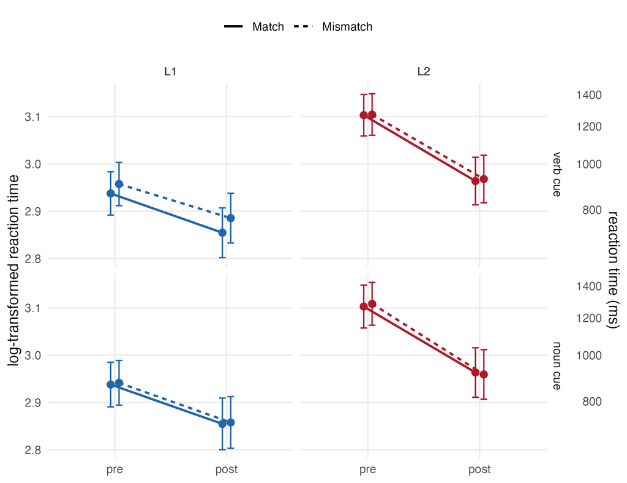

**Noun cue**

- Reaction times did not differ between mismatched and matched noun cues (Noun Match, *β* = −0.001, *SE* = 0.004, *t* = −0.13, *p* = .898), and the effect of Noun Match did not differ between the groups (Group × Noun Match, *β* = −0.009, *SE* = 0.008, *t* = −1.13, *p* = .260).
- L1 participants responded equally fast to mismatched and matched noun cues at pre (*M* = 977 ms vs. 963 ms, *z* = 0.70, *p* = .577) and at post (*M* = 833 ms vs. 820 ms, *z* = 0.56, *p* = .577).
- L2 participants responded equally fast to mismatched and matched noun cues at pre (*M* = 1534 ms vs. 1511 ms, *z* = 1.10, *p* = .577) and at post (*M* = 1081 ms vs. 1103 ms, *z* = −0.79, *p* = .577).

## Response accuracy at pre and post

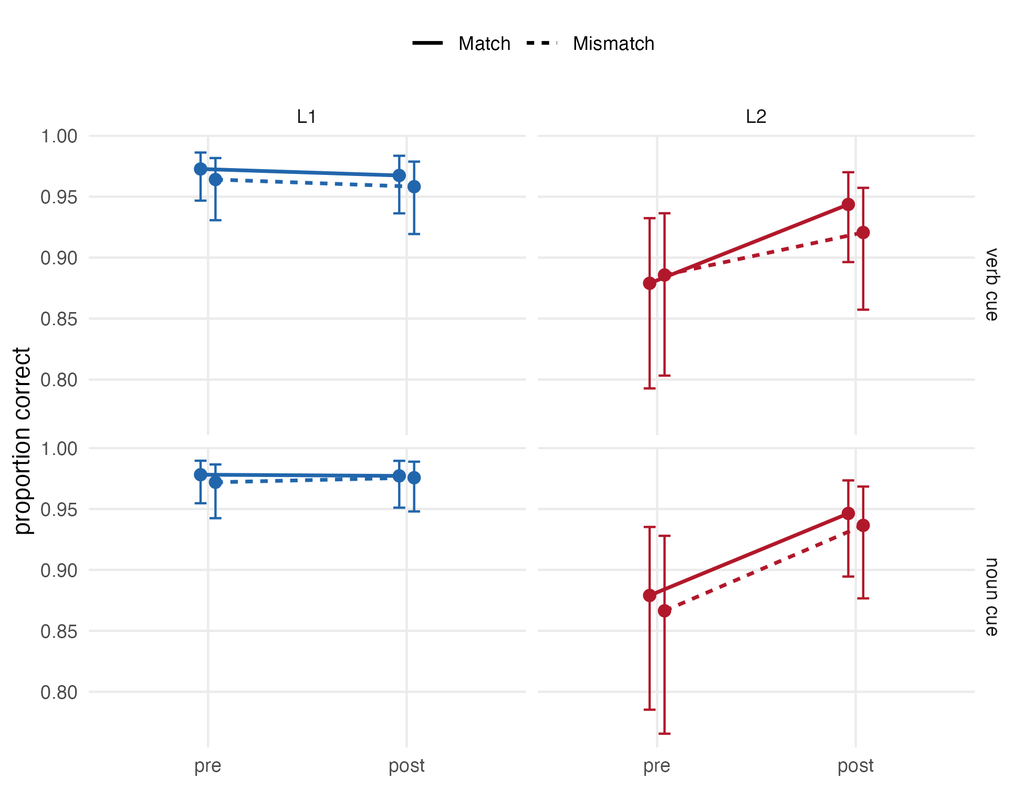

**Verb cue**

- The effect of Verb Match on accuracy changed from pre to post in the L2 group and not in the L1 group (Group × Phase × Verb Match, *β* = −0.460, *SE* = 0.194, *z* = −2.38, *p* = .018).
- L2 participants were equally accurate for mismatched and matched suffixes at pre (*M* = 81.5% vs. 80.7%, *z* = 0.87, *p* = .384) and less accurate for mismatched than for matched suffixes at post (*M* = 84.7% vs. 88.0%, *z* = −4.19, *p* < .001).
- L1 participants were less accurate for mismatched than for matched suffixes at pre (*M* = 89.3% vs. 91.1%, *z* = −2.56, *p* = .021) and at post (*M* = 89.1% vs. 90.8%, *z* = −2.38, *p* = .023).
- L2 participants were less accurate than L1 participants (*M* = 81.1% vs. 90.2% at pre; Group, *β* = −1.022, *SE* = 0.449, *z* = −2.28, *p* = .023).
- Accuracy increased from pre to post in the L2 group (from 81.1% to 86.3%) and not in the L1 group (from 90.2% to 89.9%; Group × Phase, *β* = 0.790, *SE* = 0.342, *z* = 2.31, *p* = .021).

**Noun cue**

- Accuracy was lower for mismatched than for matched noun cues (*M* = 86.2% vs. 87.5%; Noun Match, *β* = −0.153, *SE* = 0.050, *z* = −3.09, *p* = .002).
- The effect of Noun Match did not differ between the groups (Group × Noun Match, *β* = 0.015, *SE* = 0.099, *z* = 0.15, *p* = .884) or between the groups across phases (Group × Phase × Noun Match, *β* = −0.255, *SE* = 0.199, *z* = −1.29, *p* = .199).
- In the L1 group, accuracy for mismatched and matched noun cues did not differ significantly at pre (*M* = 89.5% vs. 91.1%, *z* = −2.26, *p* = .095) or at post (*M* = 90.4% vs. 90.8%, *z* = −0.57, *p* = .567).
- In the L2 group, accuracy for mismatched and matched noun cues did not differ significantly at pre (*M* = 79.2% vs. 80.7%, *z* = −1.55, *p* = .162) or at post (*M* = 86.5% vs. 88.0%, *z* = −1.96, *p* = .100).

## Training

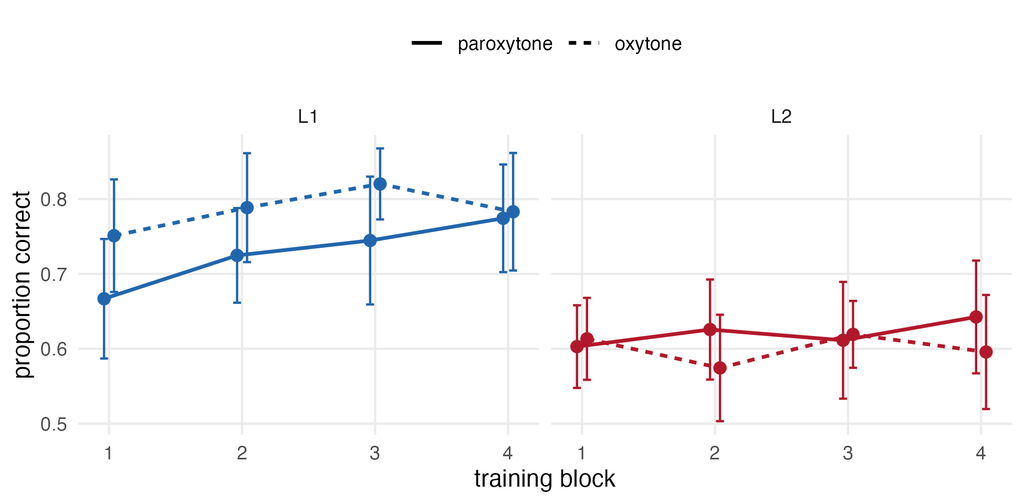

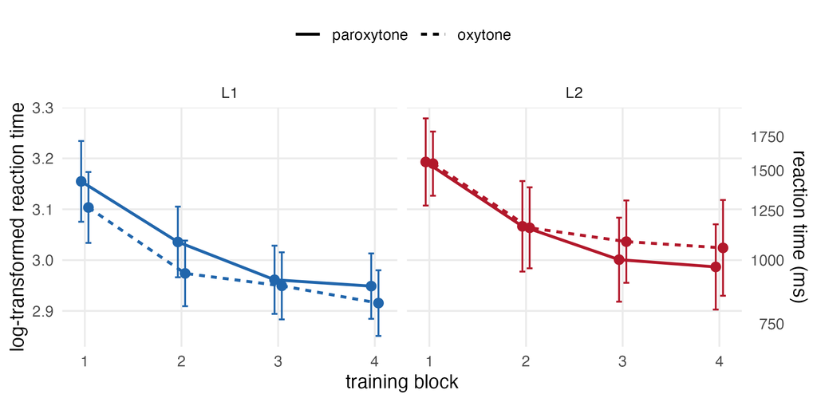

- Accuracy increased across training in the L1 group (from 70.9% in the first block to 77.8% in the last block) and changed little in the L2 group (from 60.8% to 62.0%; Trial Number, *β* = 0.392, *SE* = 0.136, *z* = 2.88, *p* = .004; Group × Trial Number, *β* = −0.562, *SE* = 0.268, *z* = −2.10, *p* = .036).
- Reaction times decreased across training in the L1 group (from 1630 ms in the first block to 1034 ms in the last block) and in the L2 group (from 1897 ms to 1296 ms; Trial Number, *β* = −0.238, *SE* = 0.028, *t* = −8.55, *p* < .001). The decrease did not differ between the groups (Group × Trial Number, *β* = −0.012, *SE* = 0.056, *t* = −0.22, *p* = .830).
- L1 participants were more accurate for oxytone than for paroxytone stems (*M* = 78.6% vs. 72.8%), and L2 participants were similarly accurate for both (*M* = 60.0% vs. 62.1%; Verb Stress, *β* = 0.251, *SE* = 0.122, *z* = 2.07, *p* = .039; Group × Verb Stress, *β* = −0.491, *SE* = 0.243, *z* = −2.02, *p* = .043).
- L1 participants responded faster to oxytone than to paroxytone stems (*M* = 1176 ms vs. 1311 ms), and L2 participants responded similarly fast to both (*M* = 1494 ms vs. 1482 ms; Verb Stress, *β* = −0.033, *SE* = 0.015, *t* = −2.09, *p* = .036; Group × Verb Stress, *β* = 0.070, *SE* = 0.031, *t* = 2.25, *p* = .025).

# ERP results

## Figures and electrodes

- The statistics were computed on the mean amplitude of all electrodes in the region of interest (ROI).
- For the PrAN, two effects were tested. The first effect is a change in the overall negativity from pre to post (Phase) or across the training blocks (Block). The second effect is a difference between oxytone and paroxytone (Verb Stress or Noun Cue).
- Each figure has one row for each group at pre and at post. Each row has the waveform, on the same y axis in every row and with negative plotted up, and the topography for that row beside it.
- The waveforms in the figures were low-pass filtered at 15 Hz for display only. The statistics were computed on the data filtered at 30 Hz.
- The topographies show the difference between the two conditions in the analysis window. The ROI electrodes are drawn as large dots.
- The waveform is shown at one ROI electrode. The electrode shown is the ROI electrode with the largest mean difference between the two conditions in the analysis window, averaged over the groups and phases.
- For the LAN of the noun violation, the mean difference was no larger than 0.04 µV at any ROI electrode. F7 is shown.
- The training figure shows F3, as for the PrAN to verb stress at pre and post. It shows the first and the last training block and the two stress patterns for each group, with the topographies of block 4 minus block 1 and of oxytone minus paroxytone.

| Component | Window | Mean difference at each ROI electrode (µV) | Electrode shown |
| --- | --- | --- | --- |
| LAN, verb violation | 225 to 300 ms | F7 −0.07, F3 −0.61, FC5 −0.50 | F3 |
| N400, verb violation | 300 to 500 ms | Cz −0.01, CP1 −0.07, CP2 −0.16, Pz −0.22 | Pz |
| P600, verb violation | 400 to 700 ms | Cz 0.23, CP1 0.39, CP2 0.28, Pz 0.40 | Pz |
| PrAN, verb stress | 136 to 280 ms | F3 −0.31, FCz −0.25, FC1 −0.31, Cz −0.17 | F3 |
| PrAN, verb stress, left anterior | 136 to 280 ms | F7 −0.25, F3 −0.31, FC5 −0.34 | FC5 |
| PrAN, noun cue | 136 to 280 ms | F3 −0.14, FCz −0.01, FC1 −0.02, Cz 0.05 | F3 |
| LAN, noun violation | 225 to 300 ms | F7 −0.01, F3 0.01, FC5 0.04 | F7 |
| N400, noun violation | 300 to 500 ms | Cz 0.05, CP1 0.20, CP2 0.09, Pz 0.22 | Pz |
| P600, noun violation | 400 to 700 ms | Cz 0.04, CP1 0.22, CP2 0.11, Pz 0.26 | Pz |

## Verb violation at the suffix

**Left anterior negativity (LAN), 225 to 300 ms, ROI F7, F3, and FC5**

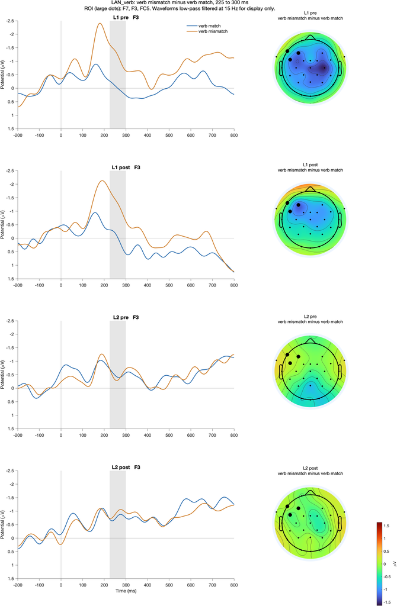

- Mismatched suffixes produced a more negative amplitude than matched suffixes (*M* = −0.68 µV vs. −0.29 µV; Verb Match, *F*(1, 38) = 7.81, *p* = .008, η<sub>p</sub><sup>2</sup> = .17), and this difference was present in the L1 group and absent in the L2 group (Group × Verb Match, *F*(1, 38) = 7.47, *p* = .009, η<sub>p</sub><sup>2</sup> = .16).
- In the L1 group, the amplitude was more negative for mismatched than for matched suffixes at pre (−0.85 µV, *p* = .037) and at post (−0.78 µV, *p* = .005).
- In the L2 group, the amplitude did not differ between mismatched and matched suffixes at pre (0.12 µV, *p* = .720) or at post (−0.14 µV, *p* = .703).

**N400, 300 to 500 ms, ROI Cz, CP1, CP2, and Pz**

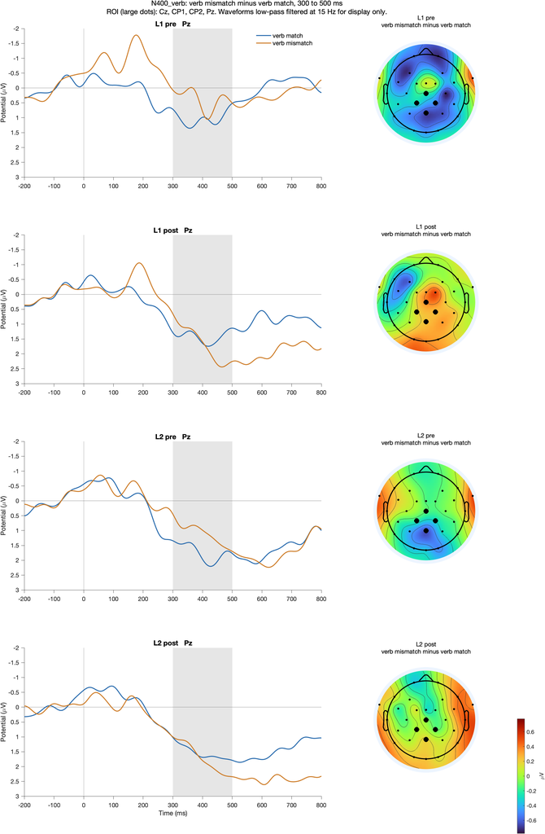

- The amplitude did not differ between mismatched and matched suffixes (Verb Match, *F*(1, 38) = 0.39, *p* = .538, η<sub>p</sub><sup>2</sup> = .01), and the difference did not vary between the groups (Group × Verb Match, *F*(1, 38) = 0.03, *p* = .855, η<sub>p</sub><sup>2</sup> = .00) or between the groups across phases (Group × Phase × Verb Match, *F*(1, 38) = 0.36, *p* = .549, η<sub>p</sub><sup>2</sup> = .01).
- The difference between mismatched and matched suffixes was not significant for L1 at pre (−0.42 µV, *p* = .559), L1 at post (0.25 µV, *p* = .661), L2 at pre (−0.32 µV, *p* = .559), or L2 at post (0.02 µV, *p* = .964).
- Past suffixes produced a more positive amplitude than present suffixes (*M* = 1.29 µV vs. 0.39 µV; Verb Stress × Verb Match, *F*(1, 38) = 18.71, *p* < .001, η<sub>p</sub><sup>2</sup> = .33). In this design the Verb Stress × Verb Match interaction is the comparison of past and present suffixes.

**P600, 400 to 700 ms, ROI Cz, CP1, CP2, and Pz**

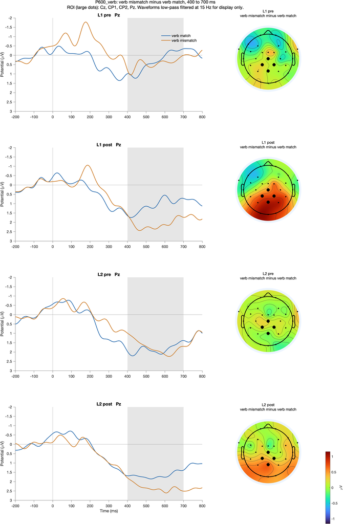

- The amplitude did not differ significantly between mismatched and matched suffixes (*M* = 0.95 µV vs. 0.62 µV; Verb Match, *F*(1, 38) = 3.87, *p* = .057, η<sub>p</sub><sup>2</sup> = .09), and the difference did not vary between the groups (Group × Verb Match, *F*(1, 38) = 0.41, *p* = .528, η<sub>p</sub><sup>2</sup> = .01) or between the groups across phases (Group × Phase × Verb Match, *F*(1, 38) = 0.35, *p* = .556, η<sub>p</sub><sup>2</sup> = .01).
- The difference between mismatched and matched suffixes was not significant for L1 at pre (0.13 µV, *p* = .726), L1 at post (0.75 µV, *p* = .176), L2 at pre (0.10 µV, *p* = .726), or L2 at post (0.34 µV, *p* = .637).
- Past suffixes produced a more positive amplitude than present suffixes (*M* = 1.20 µV vs. 0.36 µV; Verb Stress × Verb Match, *F*(1, 38) = 26.45, *p* < .001, η<sub>p</sub><sup>2</sup> = .41).

## Verb stress at verb F0

**Pre-activation negativity (PrAN), 136 to 280 ms, ROI F3, FCz, FC1, and Cz**

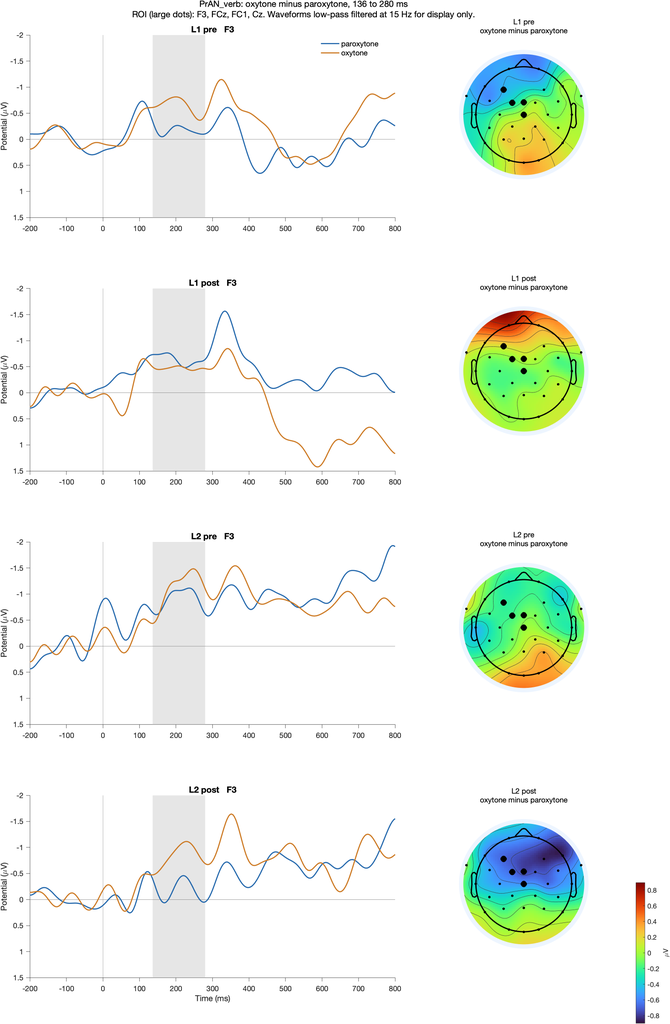

- The overall amplitude did not change from pre to post (Phase, *F*(1, 38) = 1.49, *p* = .229, η<sub>p</sub><sup>2</sup> = .04), and the change differed between the groups (Group × Phase, *F*(1, 38) = 4.48, *p* = .041, η<sub>p</sub><sup>2</sup> = .10).
- In the L2 group, the amplitude was less negative at post than at pre (*M* = −0.71 µV vs. −1.17 µV). In the L1 group, the amplitude was −0.68 µV at post and −0.56 µV at pre.
- Oxytone stems produced a more negative amplitude than paroxytone stems (*M* = −0.92 µV vs. −0.66 µV; Verb Stress, *F*(1, 38) = 5.12, *p* = .029, η<sub>p</sub><sup>2</sup> = .12).
- The difference between oxytone and paroxytone stems did not vary between the groups (Group × Verb Stress, *F*(1, 38) = 1.77, *p* = .191, η<sub>p</sub><sup>2</sup> = .04) or between the groups across phases (Group × Phase × Verb Stress, *F*(1, 38) = 2.23, *p* = .143, η<sub>p</sub><sup>2</sup> = .06).
- The difference between oxytone and paroxytone stems was not significant for L1 at pre (−0.22 µV, *p* = .559), L1 at post (0.01 µV, *p* = .964), L2 at pre (−0.14 µV, *p* = .637), or L2 at post (−0.67 µV, *p* = .072).
- Verbs that followed an oxytone noun cue produced a more negative amplitude than verbs that followed a paroxytone noun cue (*M* = −0.97 µV vs. −0.61 µV; Verb Stress × Noun Match, *F*(1, 38) = 4.91, *p* = .033, η<sub>p</sub><sup>2</sup> = .11). In this design the Verb Stress × Noun Match interaction is the comparison of the two noun cues.

**PrAN at the left anterior electrodes, 136 to 280 ms, ROI F7, F3, and FC5**

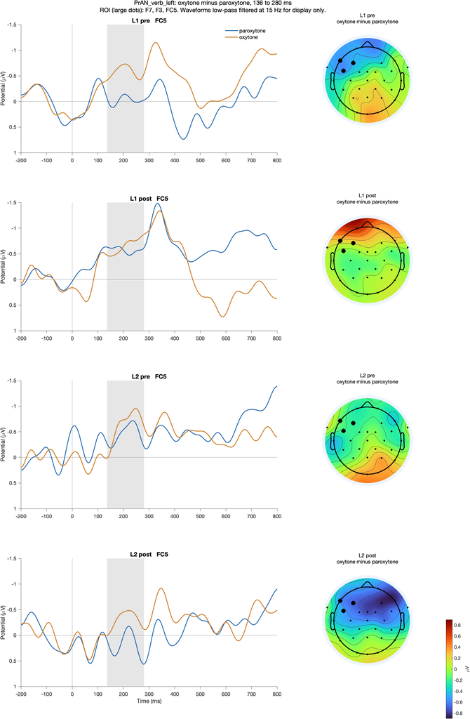

- Oxytone stems produced a more negative amplitude than paroxytone stems (*M* = −0.59 µV vs. −0.29 µV; Verb Stress, *F*(1, 38) = 7.55, *p* = .009, η<sub>p</sub><sup>2</sup> = .17).
- The difference between oxytone and paroxytone stems changed from pre to post in opposite directions in the two groups (Group × Phase × Verb Stress, *F*(1, 38) = 5.12, *p* = .029, η<sub>p</sub><sup>2</sup> = .12).
- In the L1 group, the amplitude was more negative for oxytone than for paroxytone stems at pre (−0.53 µV, *p* = .037) and did not differ at post (0.10 µV, *p* = .669).
- In the L2 group, the amplitude did not differ between oxytone and paroxytone stems at pre (−0.18 µV, *p* = .498) and was more negative for oxytone than for paroxytone stems at post (−0.58 µV, *p* = .037).
- The overall amplitude changed from pre to post in opposite directions in the two groups (Group × Phase, *F*(1, 38) = 11.04, *p* = .002, η<sub>p</sub><sup>2</sup> = .23). The amplitude was more negative at post than at pre in the L1 group (*M* = −0.46 µV vs. −0.19 µV) and less negative at post than at pre in the L2 group (*M* = −0.27 µV vs. −0.82 µV).

**PrAN after a matched and after a mismatched noun cue**

- The difference between oxytone and paroxytone stems was computed separately for the sentences in which the noun cue matched the verb stem and for the sentences in which the noun cue mismatched the verb stem.
- In the centrofrontal ROI, oxytone stems were more negative than paroxytone stems after a matched noun cue (*M* = −1.15 µV vs. −0.53 µV) and not after a mismatched noun cue (*M* = −0.69 µV vs. −0.79 µV; Verb Stress × Noun Match, *F*(1, 38) = 4.91, *p* = .033, η<sub>p</sub><sup>2</sup> = .11).
- In the left anterior ROI, the difference between oxytone and paroxytone stems was also larger after a matched noun cue than after a mismatched noun cue (matched noun cue, *M* = −0.74 µV vs. −0.21 µV; mismatched noun cue, *M* = −0.44 µV vs. −0.37 µV), and the interaction was not significant (*F*(1, 38) = 2.19, *p* = .147, η<sub>p</sub><sup>2</sup> = .05).
- After a matched noun cue, the difference was most negative for L1 at pre and for L2 at post in both ROIs. No comparison in the table was significant after FDR correction for the eight comparisons of each ROI.
- The Verb Stress × Noun Match interaction is the same test as the comparison of the two noun cues, so this design does not separate a PrAN that depends on agreement between the noun cue and the verb stem from two effects that add together.

Oxytone minus paroxytone stems at verb F0, 136 to 280 ms, with FDR-corrected p values

| ROI | Group | Phase | Noun cue matched | Noun cue mismatched |
| --- | --- | --- | --- | --- |
| Centrofrontal (F3, FCz, FC1, Cz) | L1 | pre | −0.88 µV (p = .057) | 0.43 µV (p = .663) |
| Centrofrontal (F3, FCz, FC1, Cz) | L1 | post | −0.33 µV (p = .663) | 0.36 µV (p = .663) |
| Centrofrontal (F3, FCz, FC1, Cz) | L2 | pre | −0.18 µV (p = .663) | −0.09 µV (p = .794) |
| Centrofrontal (F3, FCz, FC1, Cz) | L2 | post | −1.09 µV (p = .057) | −0.25 µV (p = .663) |
| Left anterior (F7, F3, FC5) | L1 | pre | −0.79 µV (p = .084) | −0.27 µV (p = .657) |
| Left anterior (F7, F3, FC5) | L1 | post | −0.08 µV (p = .842) | 0.29 µV (p = .657) |
| Left anterior (F7, F3, FC5) | L2 | pre | −0.29 µV (p = .657) | −0.08 µV (p = .842) |
| Left anterior (F7, F3, FC5) | L2 | post | −0.94 µV (p = .084) | −0.22 µV (p = .657) |

**Noun cue and verb stress at verb F0, with all six conditions, 136 to 280 ms**

- All six conditions were analysed with Noun Cue (paroxytone cue in conditions 1, 2, and 3; oxytone cue in conditions 4, 5, and 6) and Verb Stress (paroxytone stems in conditions 1, 3, and 4; oxytone stems in conditions 2, 5, and 6). The conditions with a mismatched suffix were included, because the suffix follows verb F0.

*Noun cue*

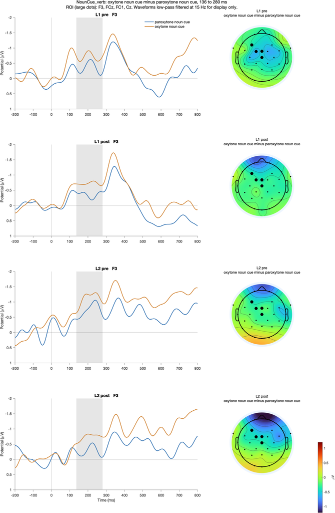

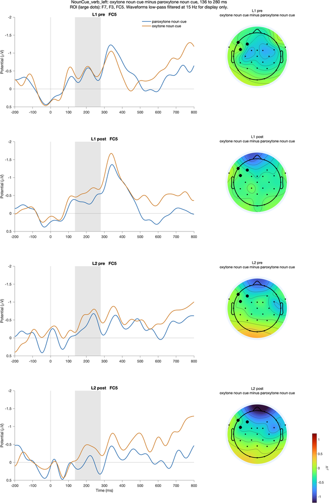

- In the centrofrontal ROI, verbs after an oxytone noun cue were more negative than verbs after a paroxytone noun cue (*M* = −0.93 µV vs. −0.61 µV; Noun Cue, *F*(1, 38) = 6.13, *p* = .018, η<sub>p</sub><sup>2</sup> = .14).
- In the left anterior ROI, the effect of the noun cue was not significant (*M* = −0.52 µV vs. −0.33 µV; Noun Cue, *F*(1, 38) = 2.22, *p* = .145, η<sub>p</sub><sup>2</sup> = .06).

*Verb stress*

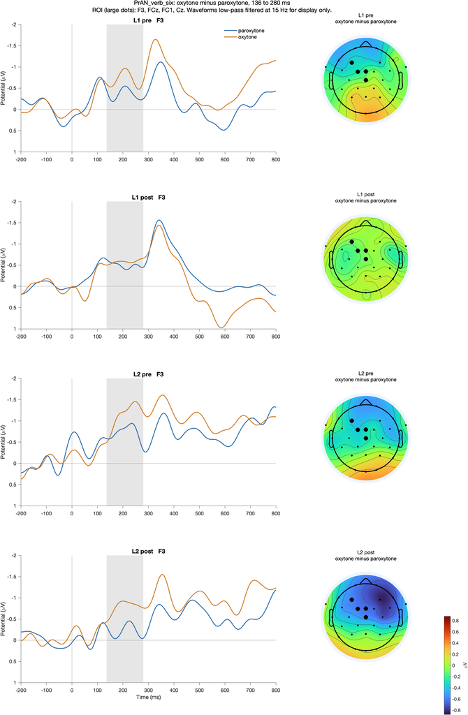

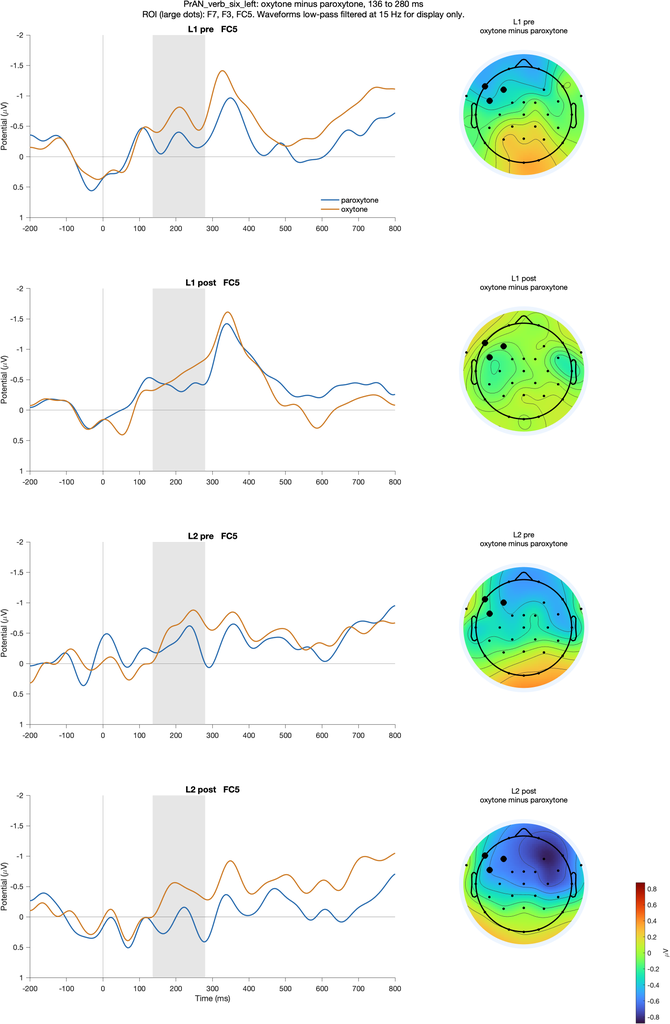

- In the centrofrontal ROI, oxytone stems were more negative than paroxytone stems (*M* = −0.89 µV vs. −0.66 µV; Verb Stress, *F*(1, 38) = 4.74, *p* = .036, η<sub>p</sub><sup>2</sup> = .11).
- In the left anterior ROI, oxytone stems were more negative than paroxytone stems (*M* = −0.56 µV vs. −0.30 µV; Verb Stress, *F*(1, 38) = 7.70, *p* = .009, η<sub>p</sub><sup>2</sup> = .17).

*Verb stress after each noun cue*

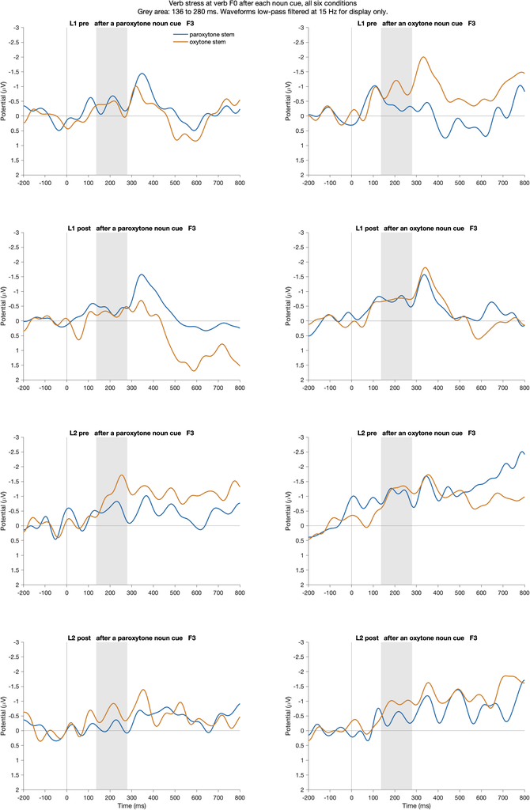

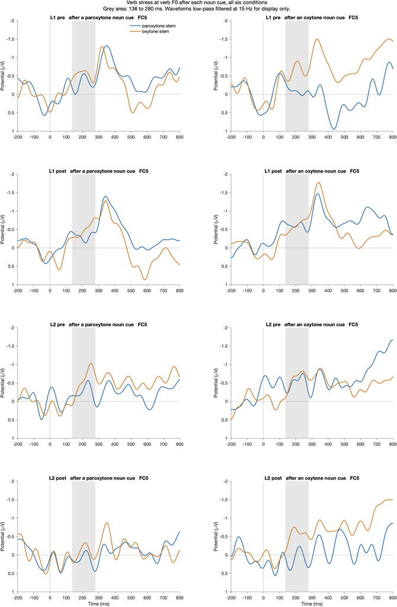

- The figures show paroxytone and oxytone stems after a paroxytone noun cue (left panels) and after an oxytone noun cue (right panels), at F3 and at FC5.
- In the centrofrontal ROI, the difference between oxytone and paroxytone stems did not depend on the noun cue (after an oxytone noun cue, *M* = −1.08 µV vs. −0.79 µV; after a paroxytone noun cue, *M* = −0.69 µV vs. −0.53 µV; Noun Cue × Verb Stress, *F*(1, 38) = 0.26, *p* = .615, η<sub>p</sub><sup>2</sup> = .01).
- In the left anterior ROI, the difference between oxytone and paroxytone stems did not depend on the noun cue (Noun Cue × Verb Stress, *F*(1, 38) = 0.22, *p* = .641, η<sub>p</sub><sup>2</sup> = .01).
- No comparison in the table was significant after FDR correction for the eight comparisons of each ROI.
- The noun cue and verb stress therefore had separate effects on the amplitude at verb F0. In the four conditions with a matched suffix, a matched noun cue adds the effect of the noun cue to the effect of verb stress, and a mismatched noun cue subtracts it.

Oxytone minus paroxytone stems at verb F0, 136 to 280 ms, all six conditions, with FDR-corrected p values

| ROI | Group | Phase | After an oxytone noun cue | After a paroxytone noun cue |
| --- | --- | --- | --- | --- |
| Centrofrontal (F3, FCz, FC1, Cz) | L1 | pre | −0.22 µV (p = .854) | 0.12 µV (p = .854) |
| Centrofrontal (F3, FCz, FC1, Cz) | L1 | post | −0.04 µV (p = .869) | 0.08 µV (p = .869) |
| Centrofrontal (F3, FCz, FC1, Cz) | L2 | pre | −0.26 µV (p = .854) | −0.34 µV (p = .471) |
| Centrofrontal (F3, FCz, FC1, Cz) | L2 | post | −0.58 µV (p = .199) | −0.45 µV (p = .471) |
| Left anterior (F7, F3, FC5) | L1 | pre | −0.66 µV (p = .362) | −0.05 µV (p = .970) |
| Left anterior (F7, F3, FC5) | L1 | post | 0.02 µV (p = .970) | 0.01 µV (p = .970) |
| Left anterior (F7, F3, FC5) | L2 | pre | −0.03 µV (p = .970) | −0.46 µV (p = .170) |
| Left anterior (F7, F3, FC5) | L2 | post | −0.57 µV (p = .170) | −0.31 µV (p = .481) |

**Each stress pattern at pre and at post**

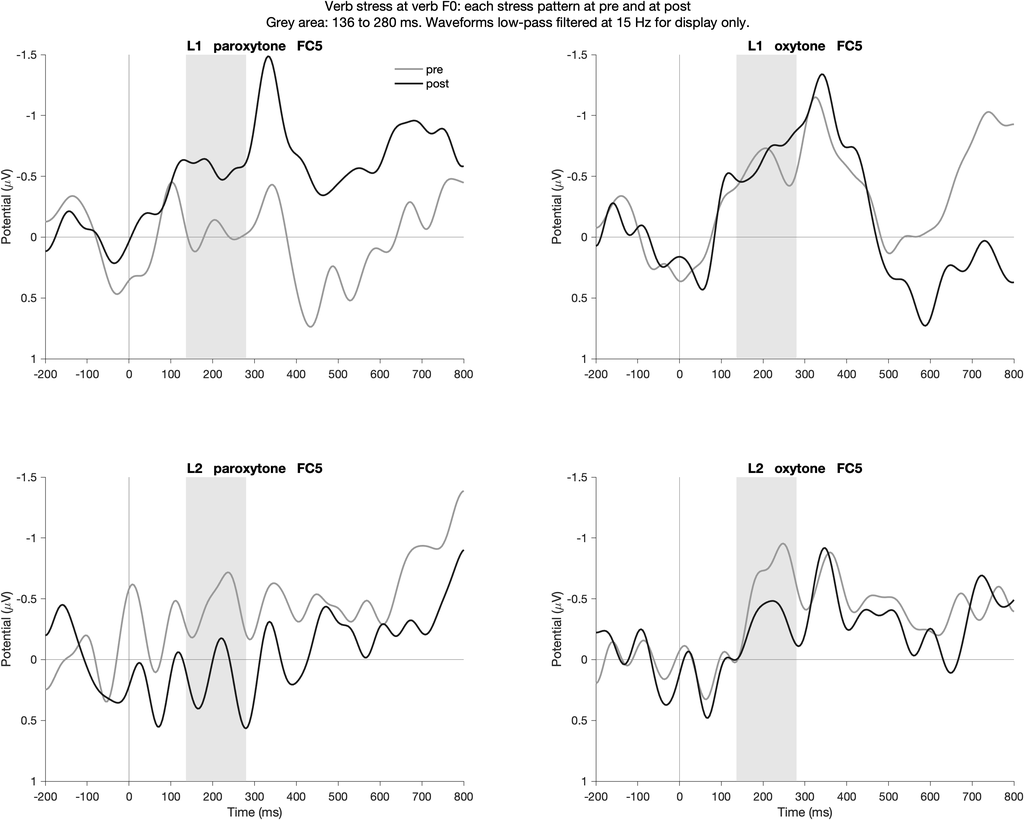

- The figure shows paroxytone and oxytone stems separately, with pre and post in the same panel, at FC5. The four conditions with a matched suffix are included.
- In the L2 group, the amplitude for paroxytone stems was less negative at post than at pre in the left anterior ROI (*M* = 0.02 µV vs. −0.73 µV; post minus pre, 0.75 µV, *p* = .021) and in the centrofrontal ROI (0.73 µV, *p* = .033). The amplitude for oxytone stems did not change significantly (left anterior, 0.35 µV, *p* = .141; centrofrontal, 0.20 µV, *p* = .596).
- In the L1 group, the amplitude for paroxytone stems was more negative at post than at pre in the left anterior ROI (*M* = −0.51 µV vs. 0.08 µV), and this change was not significant after FDR correction (−0.59 µV, *p* = .064; centrofrontal, −0.24 µV, *p* = .596). The amplitude for oxytone stems did not change (left anterior, 0.04 µV, *p* = .861; centrofrontal, −0.01 µV, *p* = .979).
- The change in the difference between oxytone and paroxytone stems from pre to post was therefore due to the paroxytone stems in both groups. The paroxytone stems became more negative in the L1 group and less negative in the L2 group, and the oxytone stems did not change.
- The *p* values were corrected for the false discovery rate over the four comparisons of each ROI.

## Noun cue at noun F0

**PrAN, 136 to 280 ms, ROI F3, FCz, FC1, and Cz**

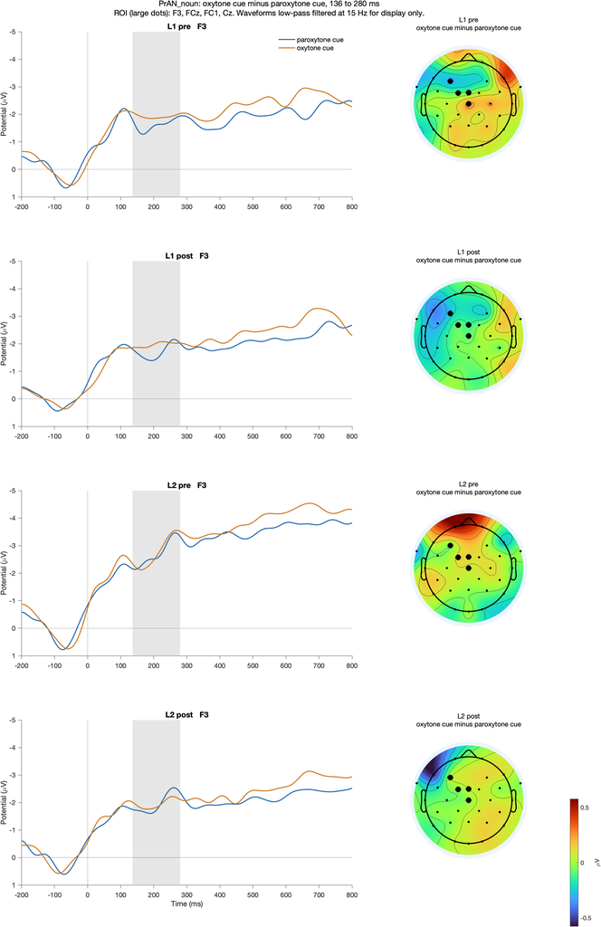

- The overall amplitude was less negative at post than at pre (*M* = −1.98 µV vs. −2.47 µV; Phase, *F*(1, 38) = 5.14, *p* = .029, η<sub>p</sub><sup>2</sup> = .12). The amplitude changed from −1.83 µV to −1.67 µV in the L1 group and from −3.05 µV to −2.26 µV in the L2 group, and the change did not differ between the groups (Group × Phase, *F*(1, 38) = 2.36, *p* = .133, η<sub>p</sub><sup>2</sup> = .06).
- The amplitude did not differ between oxytone and paroxytone noun cues (*M* = −2.24 µV vs. −2.21 µV; Noun Cue, *F*(1, 38) = 0.13, *p* = .720, η<sub>p</sub><sup>2</sup> = .00), and the difference did not vary between the groups (Group × Noun Cue, *F*(1, 38) = 0.49, *p* = .489, η<sub>p</sub><sup>2</sup> = .01) or between the groups across phases (Group × Phase × Noun Cue, *F*(1, 38) = 0.00, *p* = .995, η<sub>p</sub><sup>2</sup> = .00).
- The difference between oxytone and paroxytone noun cues was not significant for L1 at pre (−0.07 µV, *p* = .985), L1 at post (−0.13 µV, *p* = .985), L2 at pre (0.06 µV, *p* = .985), or L2 at post (0.00 µV, *p* = .999).

**Early part of the PrAN window, 136 to 200 ms**

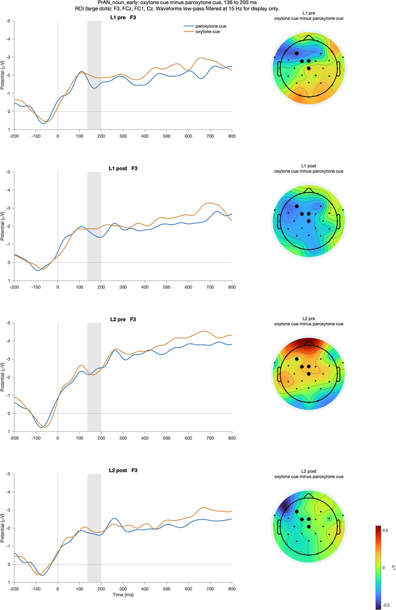

- The waveform is shown at F3, which is in both ROIs. The large dots in the topographies are the centrofrontal electrodes (F3, FCz, FC1, and Cz).
- At the left anterior electrodes (F7, F3, and FC5), oxytone noun cues produced a more negative amplitude than paroxytone noun cues (*M* = −1.68 µV vs. −1.44 µV; Noun Cue, *F*(1, 38) = 5.43, *p* = .025, η<sub>p</sub><sup>2</sup> = .12). The difference did not vary between the groups (Group × Noun Cue, *F*(1, 38) = 1.86, *p* = .180, η<sub>p</sub><sup>2</sup> = .05) or between the groups across phases (Group × Phase × Noun Cue, *F*(1, 38) = 0.95, *p* = .335, η<sub>p</sub><sup>2</sup> = .02).
- At the left anterior electrodes, the difference between oxytone and paroxytone noun cues was negative for L1 at pre (−0.41 µV, *p* = .182), L1 at post (−0.37 µV, *p* = .182), and L2 at post (−0.32 µV, *p* = .182), and it was close to zero for L2 at pre (0.12 µV, *p* = .618). No pairwise comparison was significant after FDR correction.
- At the centrofrontal electrodes (F3, FCz, FC1, and Cz), the amplitude did not differ between oxytone and paroxytone noun cues (*M* = −2.09 µV vs. −1.97 µV; Noun Cue, *F*(1, 38) = 1.45, *p* = .236, η<sub>p</sub><sup>2</sup> = .04), and the difference did not vary between the groups (Group × Noun Cue, *F*(1, 38) = 1.70, *p* = .201, η<sub>p</sub><sup>2</sup> = .04) or between the groups across phases (Group × Phase × Noun Cue, *F*(1, 38) = 0.08, *p* = .776, η<sub>p</sub><sup>2</sup> = .00).
- At the centrofrontal electrodes, the difference was not significant for L1 at pre (−0.19 µV, *p* = .548), L1 at post (−0.32 µV, *p* = .449), L2 at pre (0.13 µV, *p* = .548), or L2 at post (−0.11 µV, *p* = .548).

**Acoustic difference between the two noun cues**

- Each item has two recordings of the noun. The paroxytone cue is the noun recorded before a paroxytone verb, and the oxytone cue is the noun recorded before an oxytone verb. The 60 nouns all have two syllables with stress on the first syllable.
- The noun was shorter in the oxytone cue than in the paroxytone cue (*M* = 366 ms vs. 416 ms, *t*(59) = −11.59, *p* < .001). The interval from the noun F0 event to the onset of the verb was 275 ms in the oxytone cue and 320 ms in the paroxytone cue.
- The first syllable was shorter in the oxytone cue than in the paroxytone cue (*M* = 214 ms vs. 235 ms, *t*(59) = −5.04, *p* < .001), and the second syllable was also shorter (*M* = 151 ms vs. 180 ms, *t*(59) = −8.77, *p* < .001). The second syllable began 123 ms after the noun F0 event in the oxytone cue and 139 ms after it in the paroxytone cue.
- The fundamental frequency of the second syllable was lower in the oxytone cue than in the paroxytone cue (*M* = 17.16 vs. 17.76 semitones; difference −0.60 semitones, *t*(59) = −10.49, *p* < .001). The fundamental frequency of the first syllable was also lower in the oxytone cue (*M* = 14.79 vs. 15.61 semitones; difference −0.82 semitones, *t*(59) = −12.20, *p* < .001), and the difference was present in the first 50 ms after the noun F0 event (−0.73 semitones, *t*(59) = −10.68, *p* < .001).
- The rise in fundamental frequency from the first to the second syllable was larger in the oxytone cue than in the paroxytone cue (*M* = 2.37 vs. 2.15 semitones, *t*(59) = 3.42, *p* = .001).
- The peak of the fundamental frequency was lower in the oxytone cue (−0.75 semitones, *t*(59) = −9.61, *p* < .001) and occurred 204 ms after the noun F0 event in the oxytone cue and 212 ms after it in the paroxytone cue.
- The intensity of the second syllable was lower in the oxytone cue (−0.9 dB, *t*(59) = −3.82, *p* < .001), and the intensity of the first syllable was also lower (−1.5 dB, *t*(59) = −6.02, *p* < .001).
- The two noun cues therefore differed in duration, fundamental frequency, and intensity in both syllables, and the difference in fundamental frequency began at the noun F0 event.

Fundamental frequency of the noun in semitones relative to 100 Hz. Items without voicing in a time range in either version are not included in that row.

| Time after the noun F0 event (ms) | Items | Paroxytone cue | Oxytone cue | Difference | t | p |
| --- | --- | --- | --- | --- | --- | --- |
| 0 to 50 | 60 | 15.07 | 14.35 | −0.73 | −10.68 | < .001 |
| 50 to 100 | 59 | 15.68 | 14.91 | −0.77 | −8.67 | < .001 |
| 100 to 150 | 47 | 16.41 | 15.70 | −0.71 | −6.61 | < .001 |
| 150 to 200 | 43 | 17.51 | 16.95 | −0.56 | −4.57 | < .001 |
| 200 to 250 | 54 | 18.05 | 17.29 | −0.77 | −7.87 | < .001 |
| 250 to 300 | 50 | 17.64 | 16.74 | −0.90 | −8.25 | < .001 |

## Noun violation at verb F0

**LAN, 225 to 300 ms, ROI F7, F3, and FC5**

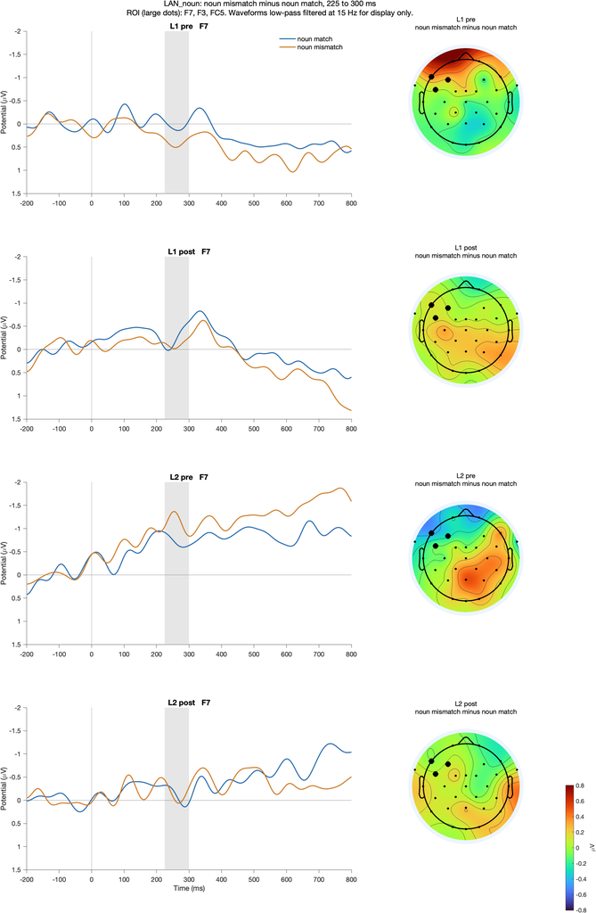

- The amplitude did not differ between mismatched and matched noun cues (*M* = −0.42 µV vs. −0.43 µV; Noun Match, *F*(1, 38) = 0.02, *p* = .881, η<sub>p</sub><sup>2</sup> = .00), and the difference did not vary between the groups (Group × Noun Match, *F*(1, 38) = 1.14, *p* = .293, η<sub>p</sub><sup>2</sup> = .03) or between the groups across phases (Group × Phase × Noun Match, *F*(1, 38) = 0.54, *p* = .466, η<sub>p</sub><sup>2</sup> = .01).
- The difference between mismatched and matched noun cues was not significant for L1 at pre (0.21 µV, *p* = .849), L1 at post (0.11 µV, *p* = .849), L2 at pre (−0.27 µV, *p* = .849), or L2 at post (0.03 µV, *p* = .891).

**N400, 300 to 500 ms, ROI Cz, CP1, CP2, and Pz**

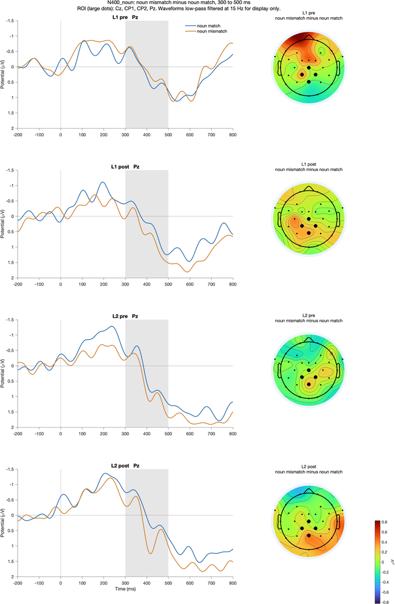

- The amplitude did not differ between mismatched and matched noun cues (*M* = −0.04 µV vs. −0.18 µV; Noun Match, *F*(1, 38) = 0.94, *p* = .339, η<sub>p</sub><sup>2</sup> = .02), and the difference did not vary between the groups (Group × Noun Match, *F*(1, 38) = 0.00, *p* = .978, η<sub>p</sub><sup>2</sup> = .00) or between the groups across phases (Group × Phase × Noun Match, *F*(1, 38) = 0.03, *p* = .859, η<sub>p</sub><sup>2</sup> = .00).
- The difference between mismatched and matched noun cues was not significant for L1 at pre (0.07 µV, *p* = .810), L1 at post (0.22 µV, *p* = .810), L2 at pre (0.12 µV, *p* = .810), or L2 at post (0.16 µV, *p* = .810).

**P600, 400 to 700 ms, ROI Cz, CP1, CP2, and Pz**

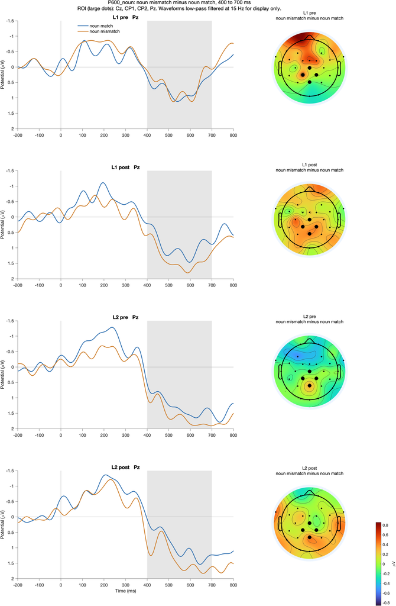

- The amplitude did not differ between mismatched and matched noun cues (*M* = 0.64 µV vs. 0.48 µV; Noun Match, *F*(1, 38) = 1.10, *p* = .301, η<sub>p</sub><sup>2</sup> = .03), and the difference did not vary between the groups (Group × Noun Match, *F*(1, 38) = 0.25, *p* = .621, η<sub>p</sub><sup>2</sup> = .01) or between the groups across phases (Group × Phase × Noun Match, *F*(1, 38) = 0.03, *p* = .854, η<sub>p</sub><sup>2</sup> = .00).
- The difference between mismatched and matched noun cues was not significant for L1 at pre (0.14 µV, *p* = .902), L1 at post (0.34 µV, *p* = .844), L2 at pre (0.04 µV, *p* = .907), or L2 at post (0.13 µV, *p* = .902).

## Verb stress at verb F0 during training

**PrAN, 136 to 280 ms, ROI F3, FCz, FC1, and Cz**

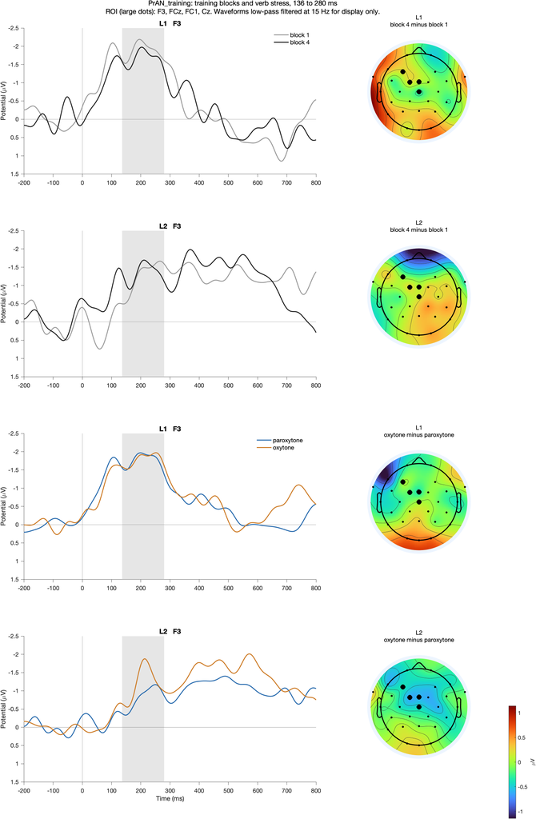

- The overall amplitude did not change across the four training blocks (Block, *F*(2.68, 101.98) = 1.54, *p* = .212, η<sub>p</sub><sup>2</sup> = .04), and the change did not differ between the groups (Group × Block, *F*(2.68, 101.98) = 0.33, *p* = .780, η<sub>p</sub><sup>2</sup> = .01).
- The mean amplitude in blocks 1 to 4 was −1.90, −2.11, −1.49, and −1.85 µV in the L1 group and −1.73, −1.42, −0.74, and −1.63 µV in the L2 group.
- The amplitude did not differ between oxytone and paroxytone stems (*M* = −1.76 µV vs. −1.43 µV; Verb Stress, *F*(1, 38) = 1.82, *p* = .185, η<sub>p</sub><sup>2</sup> = .05), and the difference did not vary between the groups (Group × Verb Stress, *F*(1, 38) = 0.61, *p* = .438, η<sub>p</sub><sup>2</sup> = .02), across blocks (Block × Verb Stress, *F*(2.63, 99.93) = 1.49, *p* = .226, η<sub>p</sub><sup>2</sup> = .04), or between the groups across blocks (Group × Block × Verb Stress, *F*(2.63, 99.93) = 1.16, *p* = .325, η<sub>p</sub><sup>2</sup> = .03).
- In the L1 group, the difference between oxytone and paroxytone stems was not significant in any block (block 1, 0.46 µV, *p* = .696; block 2, 0.51 µV, *p* = .696; block 3, −1.10 µV, *p* = .358; block 4, −0.41 µV, *p* = .696).
- In the L2 group, the difference between oxytone and paroxytone stems was not significant in any block (block 1, 0.17 µV, *p* = .752; block 2, −0.80 µV, *p* = .610; block 3, −0.27 µV, *p* = .744; block 4, −1.16 µV, *p* = .358).

**Amplitude from 600 to 800 ms and reaction time, ROI F3, FCz, FC1, and Cz**

- The amplitude from 600 to 800 ms after verb F0 did not differ between oxytone and paroxytone stems (Verb Stress, *F*(1, 38) = 0.16, *p* = .695, η<sub>p</sub><sup>2</sup> = .00), and the difference did not vary between the groups (Group × Verb Stress, *F*(1, 38) = 0.06, *p* = .809, η<sub>p</sub><sup>2</sup> = .00).
- In the L1 group, the amplitude was 0.26 µV for oxytone stems and 0.31 µV for paroxytone stems (oxytone minus paroxytone, −0.06 µV, *p* = .917). In the L2 group, the amplitude was −1.00 µV for oxytone stems and −0.76 µV for paroxytone stems (−0.23 µV, *p* = .917).
- The mean reaction time of the trials in this analysis was 1194 ms for oxytone stems and 1294 ms for paroxytone stems in the L1 group, and 1567 ms and 1522 ms in the L2 group. Reaction times were calculated from stem offset, so most responses followed the 600 to 800 ms window.
- The amplitude of each trial was analysed with Group, Verb Stress, and log-transformed Reaction Time as fixed effects and Participant and Item as random effects. The amplitude was more negative in trials with longer reaction times (Reaction Time, *β* = −1.41, *SE* = 0.70, *t* = −2.01, *p* = .044).
- The relation between the amplitude and the reaction time was significant in the L2 group (*β* = −2.58, *SE* = 0.94, *z* = −2.74, *p* = .006) and not in the L1 group (*β* = −0.23, *SE* = 1.03, *z* = −0.22, *p* = .826), and the difference between the groups was not significant (Group × Reaction Time, *β* = −2.36, *SE* = 1.40, *t* = −1.69, *p* = .091).
- The relation did not differ between oxytone and paroxytone stems (Verb Stress × Reaction Time, *β* = 1.74, *SE* = 1.25, *t* = 1.38, *p* = .167; Group × Verb Stress × Reaction Time, *β* = −0.66, *SE* = 2.51, *t* = −0.26, *p* = .793).

# All effects at *p* < .05

**Behavioural models**

| Model | Effect | β | SE | t or z | p |
| --- | --- | --- | --- | --- | --- |
| Reaction time, verb cue | Group | 0.142 | 0.033 | 4.28 | < .001 |
| Reaction time, verb cue | Phase | −0.108 | 0.010 | −10.67 | < .001 |
| Reaction time, verb cue | Accuracy | 0.032 | 0.005 | 6.90 | < .001 |
| Reaction time, verb cue | Group × Phase | −0.060 | 0.020 | −2.98 | .005 |
| Reaction time, verb cue | Group × Match | −0.028 | 0.008 | −3.53 | < .001 |
| Reaction time, verb cue | Group × Accuracy | 0.042 | 0.009 | 4.61 | < .001 |
| Reaction time, verb cue | Match × Accuracy | −0.022 | 0.008 | −2.75 | .006 |
| Reaction time, noun cue | Group | 0.145 | 0.034 | 4.24 | < .001 |
| Reaction time, noun cue | Phase | −0.114 | 0.011 | −10.49 | < .001 |
| Reaction time, noun cue | Accuracy | 0.047 | 0.005 | 9.68 | < .001 |
| Reaction time, noun cue | Group × Phase | −0.061 | 0.022 | −2.81 | .007 |
| Reaction time, noun cue | Group × Accuracy | 0.025 | 0.010 | 2.63 | .009 |
| Accuracy, verb cue | Group | −1.022 | 0.449 | −2.28 | .023 |
| Accuracy, verb cue | Match | −0.211 | 0.048 | −4.36 | < .001 |
| Accuracy, verb cue | Group × Phase | 0.790 | 0.342 | 2.31 | .021 |
| Accuracy, verb cue | Phase × Match | −0.203 | 0.097 | −2.10 | .036 |
| Accuracy, verb cue | Group × Phase × Match | −0.460 | 0.194 | −2.38 | .018 |
| Accuracy, noun cue | Group | −1.343 | 0.491 | −2.74 | .006 |
| Accuracy, noun cue | Phase | 0.452 | 0.196 | 2.31 | .021 |
| Accuracy, noun cue | Match | −0.153 | 0.050 | −3.09 | .002 |
| Accuracy, noun cue | Group × Phase | 0.803 | 0.392 | 2.05 | .040 |
| Reaction time, training | Trial Number | −0.238 | 0.028 | −8.55 | < .001 |
| Reaction time, training | Verb Stress | −0.033 | 0.015 | −2.09 | .036 |
| Reaction time, training | Group × Verb Stress | 0.070 | 0.031 | 2.25 | .025 |
| Accuracy, training | Group | −0.519 | 0.189 | −2.75 | .006 |
| Accuracy, training | Trial Number | 0.392 | 0.136 | 2.88 | .004 |
| Accuracy, training | Verb Stress | 0.251 | 0.122 | 2.07 | .039 |
| Accuracy, training | Group × Trial Number | −0.562 | 0.268 | −2.10 | .036 |
| Accuracy, training | Group × Verb Stress | −0.491 | 0.243 | −2.02 | .043 |

**ERP ANOVAs**

| Component | Effect | df | F | p | ηp² |
| --- | --- | --- | --- | --- | --- |
| PrAN, noun cue | Phase | 1, 38 | 5.14 | .029 | .12 |
| PrAN, noun cue, 136 to 200 ms, left anterior | Noun Cue | 1, 38 | 5.43 | .025 | .12 |
| PrAN, verb stress | Group × Phase | 1, 38 | 4.48 | .041 | .10 |
| PrAN, verb stress | Verb Stress | 1, 38 | 5.12 | .029 | .12 |
| PrAN, verb stress | Verb Stress × Noun Match | 1, 38 | 4.91 | .033 | .11 |
| PrAN, verb stress, left anterior | Group × Phase | 1, 38 | 11.04 | .002 | .23 |
| PrAN, verb stress, left anterior | Verb Stress | 1, 38 | 7.55 | .009 | .17 |
| PrAN, verb stress, left anterior | Group × Phase × Verb Stress | 1, 38 | 5.12 | .029 | .12 |
| LAN, noun violation | Group × Phase | 1, 38 | 11.52 | .002 | .23 |
| LAN, noun violation | Verb Stress | 1, 38 | 7.18 | .011 | .16 |
| LAN, verb violation | Verb Match | 1, 38 | 7.81 | .008 | .17 |
| LAN, verb violation | Group × Verb Match | 1, 38 | 7.47 | .009 | .16 |
| N400, verb violation | Group × Phase | 1, 38 | 6.55 | .015 | .15 |
| N400, verb violation | Verb Stress | 1, 38 | 14.17 | < .001 | .27 |
| N400, verb violation | Verb Stress × Verb Match | 1, 38 | 18.71 | < .001 | .33 |
| P600, verb violation | Phase | 1, 38 | 7.26 | .010 | .16 |
| P600, verb violation | Group × Phase | 1, 38 | 12.43 | .001 | .25 |
| P600, verb violation | Verb Stress | 1, 38 | 20.40 | < .001 | .35 |
| P600, verb violation | Verb Stress × Verb Match | 1, 38 | 26.45 | < .001 | .41 |

# ANOVA and permutation *p* values

| Component | Effect | ANOVA p | Permutation p |
| --- | --- | --- | --- |
| LAN, verb violation | Group | .873 | .872 |
| LAN, verb violation | Phase | .672 | .681 |
| LAN, verb violation | Group × Phase | .652 | .667 |
| LAN, verb violation | Verb Stress | .289 | .291 |
| LAN, verb violation | Group × Verb Stress | .168 | .166 |
| LAN, verb violation | Verb Match | .008 | .007 |
| LAN, verb violation | Group × Verb Match | .009 | .010 |
| LAN, verb violation | Phase × Verb Stress | .748 | .748 |
| LAN, verb violation | Group × Phase × Verb Stress | .936 | .936 |
| LAN, verb violation | Phase × Verb Match | .733 | .734 |
| LAN, verb violation | Group × Phase × Verb Match | .559 | .556 |
| LAN, verb violation | Verb Stress × Verb Match | .966 | .967 |
| LAN, verb violation | Group × Verb Stress × Verb Match | .456 | .457 |
| LAN, verb violation | Phase × Verb Stress × Verb Match | .732 | .729 |
| LAN, verb violation | Group × Phase × Verb Stress × Verb Match | .357 | .354 |
| N400, verb violation | Group | .658 | .665 |
| N400, verb violation | Phase | .088 | .090 |
| N400, verb violation | Group × Phase | .015 | .015 |
| N400, verb violation | Verb Stress | < .001 | < .001 |
| N400, verb violation | Group × Verb Stress | .779 | .785 |
| N400, verb violation | Verb Match | .538 | .541 |
| N400, verb violation | Group × Verb Match | .855 | .857 |
| N400, verb violation | Phase × Verb Stress | .761 | .752 |
| N400, verb violation | Group × Phase × Verb Stress | .589 | .590 |
| N400, verb violation | Phase × Verb Match | .082 | .088 |
| N400, verb violation | Group × Phase × Verb Match | .549 | .550 |
| N400, verb violation | Verb Stress × Verb Match | < .001 | < .001 |
| N400, verb violation | Group × Verb Stress × Verb Match | .250 | .259 |
| N400, verb violation | Phase × Verb Stress × Verb Match | .742 | .748 |
| N400, verb violation | Group × Phase × Verb Stress × Verb Match | .406 | .420 |

[output cut: 141 more lines]